# Capstone Project: Bellabeat

Jennifer Floyd

May 2023

### **Background**

The premise of this project is to focus on one product from a high-tech manufacturer of health-focused products for women: Bellabeat. The goal is to provide recommendations for their marketing strategy based on existing smart device data. My role is a data analyst on the marketing analytics team, and the stakeholders are Urška Sršen: Bellabeat’s co-founder and Chief Creative Officer, Sando Mur: Mathematician and Bellabeat’s co-founder, and Bellabeat’s marketing analytics team.

For this project, I focused on the Bellabeat App to offer insights into a marketing strategy based on smart device data. The Bellabeat App connects with their smart devices to provide awareness of a user’s activity, sleep, stress, menstrual cycle, and mindfulness habits.

### **Data Preparation**

#### Basic Information

The primary smart device dataset was provided via CC0: Public Domain made available through [Mobius](https://www.kaggle.com/arashnic). It was collected from responses to a survey by Amazon Mechanical Turk between 04.12.2016-05.12.2016. Users submitted physical activity, heart rate, and sleep information from their FitBit smartwatch. This dataset contains 18 files split into daily, hourly, and minute records.

A second smart device dataset used was provided by CC0: Public Domain, made available through [Zenodo](https://zenodo.org/record/7229547). Participants contributed their data through numerous validated surveys, real-time ecological momentary assessments, and a Fitbit Sense smartwatch. The data was collected in two rounds from 05.24.2021-07.26.2021 and 11.15.2021-01.17.2022. A total of 4 months of data was collected for 71 users (*see limitation note below*). This dataset is indicated by the preceding “lifesnap” file name. This dataset contains 2 files with information split between daily and hourly records.

#### Considerations

- Primary data limitations:
  - The sample size is limited to 33 users over 1 month. This small sample size and duration could impact the accuracy of the recommendations.
  - There is no demographic information on the users provided. Bellabeat is marketed specifically for women, so the data would be skewed if any users were male.
  - There are 18 files, but I’ve chosen to focus on 6.
  - Totals from the steps/calorie hourly files do not match the totals listed in the steps/calorie daily files (*see Clean Data verification note below*), which may affect the accuracy of the recommendations.
  - The daily and hourly heart rate is one file based on seconds, then calculated to days and hours. There is potential for inaccuracies since the data was provided in a different format than the others.
  - The dataset is 7 years old, which could impact results for future marketing success.
- Secondary data limitations:
  - Data includes both men and women in the data. When removing the men, the number of participants is reduced from 71 to 27.
- All datasets were recorded at different times of the year and in different years. The change in daily life due to the global pandemic could have altered the secondary datasets when comparing them to the primary dataset, which was pre-pandemic.
- I will only use the daily and hourly files to keep a consistent tracking method between all the datasets. I will also use the calorie, steps, sleep, and heart rate for my analysis.
- The sleep data is the only data that did not have an hourly measurement in the primary dataset, so I will only be doing a daily analysis on sleep.

#### **Upload**

Installing and loading packages needed for cleaning and analyzing the data:

```r
#Install and Load Packages
#install.packages("tidyverse")
#install.packages("janitor")
#install.packages("dplyr")
#install.packages("skimr")
#install.packages("ggplot2")
#install.packages("collapse")
#install.packages("patchwork")
library(tidyverse)
library(janitor)
library(dplyr)
library(skimr)
library(ggplot2)
library(collapse)
library(patchwork)
```

Upload the primary dataset files:

```r
#Upload Primary Dataset
daily_calories <- read.csv("dailyCalories_merged.csv")
daily_steps <- read.csv("dailySteps_merged.csv")
hourly_calories <- read.csv("hourlyCalories_merged.csv")
hourly_steps <- read.csv("hourlySteps_merged.csv")
heartrate <- read.csv("heartrate_seconds_merged.csv")
daily_sleep <- read.csv("sleepDay_merged.csv")
```

Upload the secondary dataset files:

```r
#Upload Secondary Dataset
lifesnap_daily <- read.csv("Lifesnap/daily_fitbit_sema_df_unprocessed.csv")
lifesnap_hourly <- read.csv("Lifesnap/hourly_fitbit_sema_df_unprocessed.csv")
```

#### **Clean and Format**

As Bellabeat is marketing specifically to women, the males must be filtered out from the secondary dataset. We will also be selecting only the columns needed for the study. These filtered datasets will be used for the remainder of the analysis.

```r
#Filtering Lifesnap Data
filtered_lifesnap_daily <- filter(lifesnap_daily, gender == 'FEMALE') %>%
  select(id, date, calories, steps, bpm,  minutesAsleep, gender)
filtered_lifesnap_hourly <- filter(lifesnap_hourly, gender == 'FEMALE') %>%
  select(id, date, hour, calories, steps, bpm, gender)
```

Clean the column names:

```r
#Clean Names
daily_calories <- daily_calories %>% clean_names()
daily_steps <- daily_steps %>% clean_names()
hourly_calories <- hourly_calories %>% clean_names()
hourly_steps <- hourly_steps %>% clean_names()
heartrate <- heartrate %>% clean_names()
daily_sleep <- daily_sleep %>% clean_names()
filtered_lifesnap_daily <- filtered_lifesnap_daily %>% clean_names()
filtered_lifesnap_hourly <- filtered_lifesnap_hourly %>% clean_names()
```

Reformat the secondary dataset’s date format to be consistent with the primary dataset’s:

```r
#Reformat Date in Secondary
filtered_lifesnap_daily$date <- strftime(filtered_lifesnap_daily$date, format = "%m/%d/%Y", tz = "GMT")
filtered_lifesnap_hourly$date <- strftime(filtered_lifesnap_hourly$date, format = "%m/%d/%Y", tz = "GMT")
```

Rename columns for consistency:

```r
#Rename Daily Date Columns and Convert to Date Class
daily_calories = rename(daily_calories, "date" = "activity_day")
daily_calories$date <- mdy(daily_calories$date)
daily_calories$date <- strftime(daily_calories$date, "%m/%d/%Y", tz = "GMT")
daily_steps = rename(daily_steps, "date" = "activity_day")
daily_steps$date <- mdy(daily_steps$date)
daily_steps$date <- strftime(daily_steps$date, "%m/%d/%Y", tz = "GMT")
daily_sleep <- rename(daily_sleep, "minutes_asleep" = "total_minutes_asleep")
heartrate <- rename(heartrate, "bpm" = "value")
filtered_lifesnap_daily <- rename(filtered_lifesnap_daily, "minutes_asleep" = "minutes_asleep")

#Split and Rename Hourly Date and Hour Columns
hourly_calories$ActivityHour2 <- mdy_hms(hourly_calories$activity_hour)
hourly_calories$date <- strftime(hourly_calories$ActivityHour2, "%m/%d/%Y", tz = "GMT")
hourly_calories$hour <- parse_number(format(as.POSIXct(hourly_calories$ActivityHour2), format = "%H:%M:%S"))
hourly_calories <- subset(hourly_calories, select = -ActivityHour2)
hourly_steps$ActivityHour2 <- mdy_hms(hourly_steps$activity_hour)
hourly_steps$date <- strftime(hourly_steps$ActivityHour2, "%m/%d/%Y", tz = "GMT")
hourly_steps$hour <- parse_number(format(as.POSIXct(hourly_steps$ActivityHour2), format = "%H:%M:%S"))
hourly_steps <- subset(hourly_steps, select = -ActivityHour2)
daily_sleep$SleepDay2 <- mdy_hms(daily_sleep$sleep_day)
daily_sleep$date <- strftime(daily_sleep$SleepDay2, "%m/%d/%Y", tz = "GMT")
daily_sleep <- subset(daily_sleep, select = -SleepDay2)
heartrate$Time2 <- mdy_hms(heartrate$time)
heartrate$date <- strftime(heartrate$Time2, "%m/%d/%Y", tz = "GMT")
heartrate$hour <- parse_number(format(as.POSIXct(heartrate$Time2), format = "%H:%M:%S"))
heartrate <- subset(heartrate, select = -Time2)

#Convert Heart Rate id to Character
heartrate$id <- as.character(heartrate$id)
```

Break down primary heart rate data into daily and hourly summarized by id:

```r
#Summarize Heart Rate Primary Data
daily_heartrate <- heartrate
daily_heartrate <-  daily_heartrate %>%
  mutate(bpm = bpm) %>%
  bind_rows(daily_heartrate) %>%
  group_by(id, date) %>%
  summarise(bpm = mean(bpm))

hourly_heartrate <- heartrate
hourly_heartrate <- hourly_heartrate %>%
  mutate(bpm = bpm) %>%
  bind_rows(hourly_heartrate) %>%
  group_by(id, date, hour) %>%
  summarise(bpm = mean(bpm))
```

Add the day of the week to daily files:

```r
#Add Day of Week
daily_calories$day <- mdy(daily_calories$date)
daily_calories$day <- weekdays(daily_calories$day, abbreviate = FALSE)
daily_steps$day <- mdy(daily_steps$date)
daily_steps$day <- weekdays(daily_steps$day, abbreviate = FALSE)
daily_sleep$day <- mdy(daily_sleep$date)
daily_sleep$day <- weekdays(daily_sleep$day, abbreviate = FALSE)
daily_heartrate$day <- mdy(daily_heartrate$date)
daily_heartrate$day <- weekdays(daily_heartrate$day, abbreviate = FALSE)
filtered_lifesnap_daily$day <- mdy(filtered_lifesnap_daily$date)
filtered_lifesnap_daily$day <- weekdays(filtered_lifesnap_daily$day, abbreviate = FALSE)
```

Verify the primary dataset contains the same number of unique users:

```r
#Calculate Number of Primary Users
length(unique(daily_calories$id))
length(unique(hourly_steps$id))
length(unique(daily_steps$id))
length(unique(hourly_calories$id))
length(unique(daily_sleep$id))
length(unique(daily_heartrate$id))
length(unique(hourly_heartrate$id))
```

```
## [1] 33
## [1] 33
## [1] 33
## [1] 33
## [1] 24
## [1] 14
## [1] 14
```

Note: Daily sleep and heart rate have fewer users than the other primary datasets. This could affect results.

Verify the filtered secondary dataset contains the same number of unique users:

```r
#Calculate Number of Seconary Users
length(unique(filtered_lifesnap_daily$id))
length(unique(filtered_lifesnap_hourly$id))
```

```
## [1] 27
## [1] 27
```

Verify the primary data hourly dataset totals match the daily datasets:

```r
#Calculating the Calorie Difference Amounts
calories_verify <- hourly_calories %>%
  select(id, calories, date) %>%
  group_by(id, date) %>%
  summarise(total_calories=sum(calories)) %>%
  left_join(daily_calories) %>%
  mutate(calorie_difference = calories - total_calories)
tibble(calories_verify)
```

```
## # A tibble: 934 × 6
##            id date       total_calories calories day       calorie_difference
##         <dbl> <chr>               <int>    <int> <chr>                  <int>
##  1 1503960366 04/12/2016           1988     1985 Tuesday                   -3
##  2 1503960366 04/13/2016           1798     1797 Wednesday                 -1
##  3 1503960366 04/14/2016           1776     1776 Thursday                   0
##  4 1503960366 04/15/2016           1745     1745 Friday                     0
##  5 1503960366 04/16/2016           1866     1863 Saturday                  -3
##  6 1503960366 04/17/2016           1730     1728 Sunday                    -2
##  7 1503960366 04/18/2016           1920     1921 Monday                     1
##  8 1503960366 04/19/2016           2034     2035 Tuesday                    1
##  9 1503960366 04/20/2016           1785     1786 Wednesday                  1
## 10 1503960366 04/21/2016           1777     1775 Thursday                  -2
## # ℹ 924 more rows
```

```r
#Calculating the Step Difference Amounts
steps_verify <- hourly_steps %>%
  select(id, step_total, date) %>%
  group_by(id, date) %>%
  summarise(total_steps = sum(step_total)) %>%
  left_join(daily_steps) %>%
  mutate(step_difference = step_total - total_steps)
tibble(steps_verify)
```

```
## # A tibble: 934 × 6
##            id date       total_steps step_total day       step_difference
##         <dbl> <chr>            <int>      <int> <chr>               <int>
##  1 1503960366 04/12/2016       13158      13162 Tuesday                 4
##  2 1503960366 04/13/2016       10735      10735 Wednesday               0
##  3 1503960366 04/14/2016       10460      10460 Thursday                0
##  4 1503960366 04/15/2016        9685       9762 Friday                 77
##  5 1503960366 04/16/2016       12669      12669 Saturday                0
##  6 1503960366 04/17/2016        9705       9705 Sunday                  0
##  7 1503960366 04/18/2016       13019      13019 Monday                  0
##  8 1503960366 04/19/2016       15506      15506 Tuesday                 0
##  9 1503960366 04/20/2016       10544      10544 Wednesday               0
## 10 1503960366 04/21/2016        9819       9819 Thursday                0
## # ℹ 924 more rows
```

```r
#Calculating the Min, Max, and Total Differences
difference_totals_calories <- sum(calories_verify$calorie_difference)
minimum_calorie_difference <- min(calories_verify$calorie_difference)
maximum_calorie_difference <- max(calories_verify$calorie_difference)
difference_totals_steps <- sum(steps_verify$step_difference)
minimum_step_difference <- min(steps_verify$step_difference)
maximum_step_difference <- max(steps_verify$step_difference)
difference_totals_final <- data.frame(
  difference_totals_calories,
  minimum_calorie_difference,
  maximum_calorie_difference,
  difference_totals_steps,
  minimum_step_difference,
  maximum_step_difference
)
difference_totals <- pivot_longer(difference_totals_final, cols = contains("differ"), names_to = "type", values_to = "amount")
tibble(difference_totals_final)
```

```
## # A tibble: 1 × 6
##   difference_totals_calories minimum_calorie_difference maximum_calorie_differ…¹
##                        <int>                      <int>                    <int>
## 1                      13134                        -75                     2535
## # ℹ abbreviated name: ¹maximum_calorie_difference
## # ℹ 3 more variables: difference_totals_steps <int>,
## #   minimum_step_difference <int>, maximum_step_difference <int>
```

**Note: Significant differences in the primary dataset between the daily and hourly totals may affect the analysis below.**

### **Analysis**

#### Comparing Primary to Secondary Datasets

Before combining the datasets for an overall analysis, I wanted to see how the data compared. Since the datasets have vastly different date ranges, I calculated the average for comparison and then created visuals.

Note: All code for the graphs can be found in the Appendix.

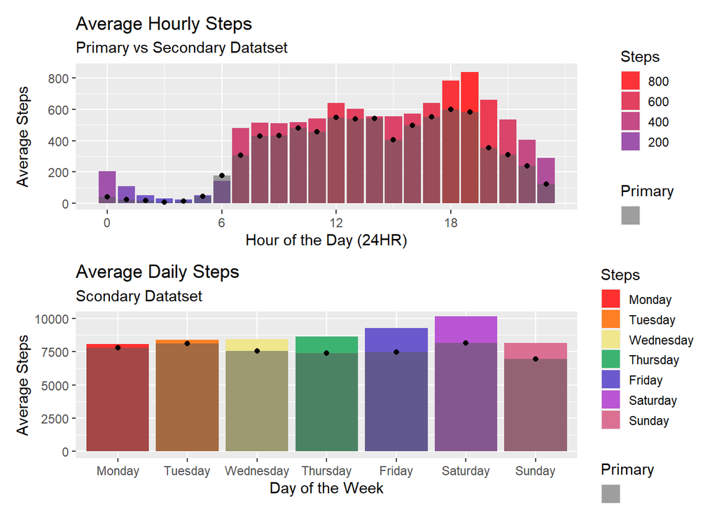

Notes:

- As you can see, the secondary dataset users were taking more steps, but compared to the calories below, this did not translate to burning more calories. The cause for this would need further study and is outside this project’s scope.

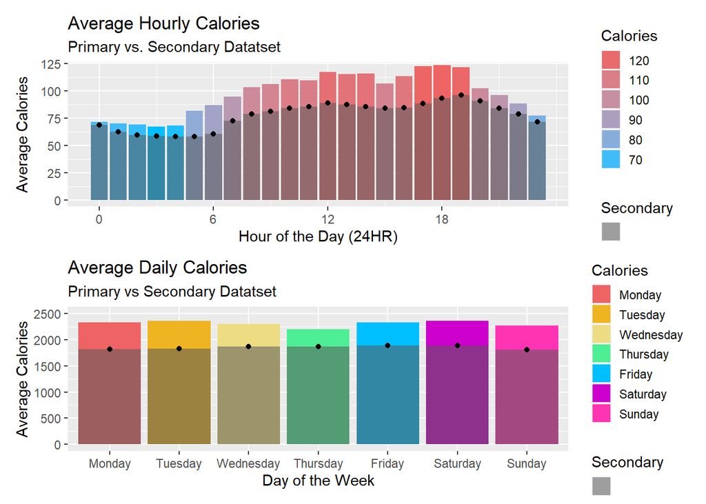

Notes:

- The hourly comparisons for both steps and calories show that the active periods during the day follow roughly the same patterns: activity starts around 6 am, dips after lunch, peaks around dinner time, and then tapers off during the evening and night. The daily comparison for steps has Saturday being the highest day, but the remaining days do not correlate.
- The daily comparison for calories shows that they are even across all the days, with the primary dataset being between 200 calories from the highest to the lowest and the secondary dataset being between 80 calories from the highest to the lowest.

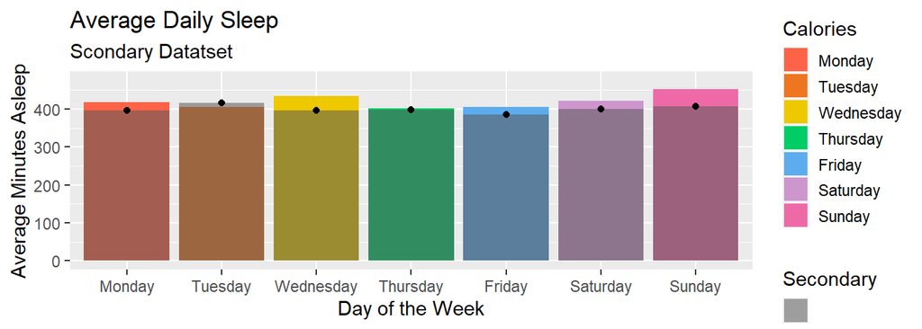

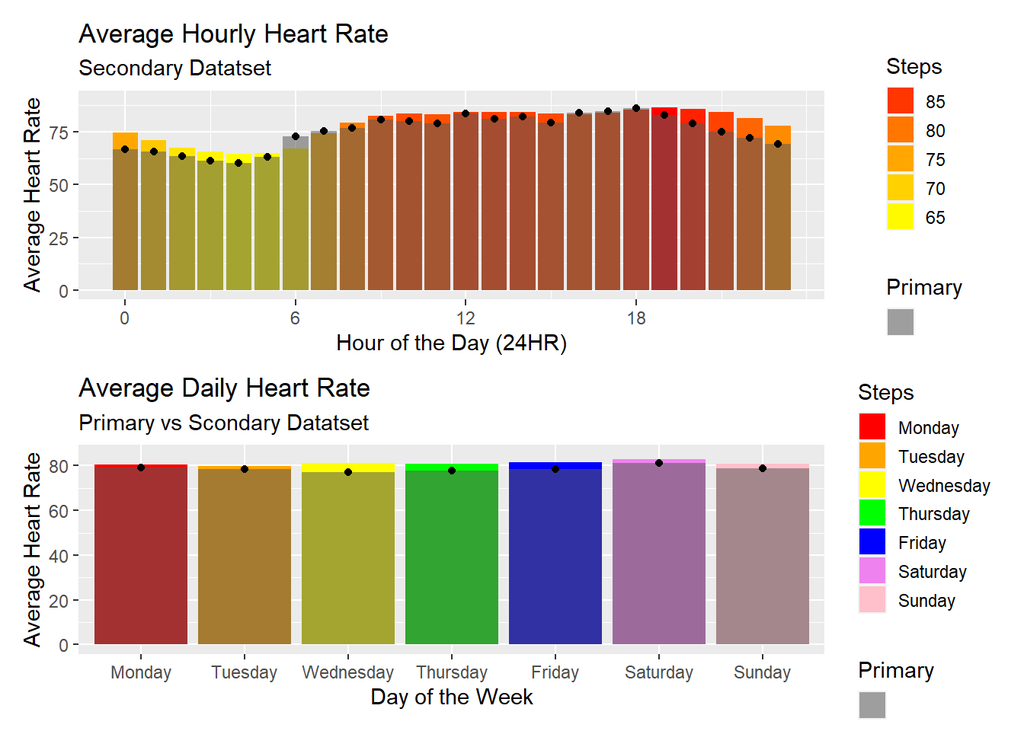

Notes:

- The comparisons of heart rate are consistent with both datasets.

#### Comparing Overall (Combined) Data

Now that we understand the individual datasets, we can combine them to complete our overall analysis. Let’s look at how the minutes asleep affects the calories, steps, and heart rate.

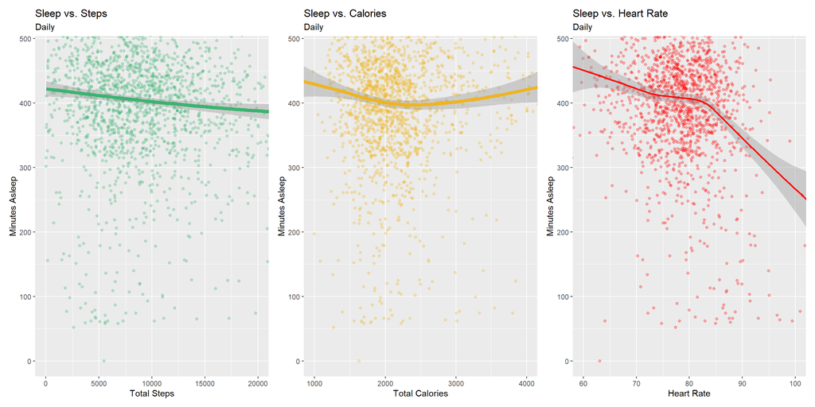

Notes:

- Each graph is set to an 8-hour window for sleep. The average user got around 400 minutes of sleep (6 hours and 40 minutes). There is no data for hourly sleep.
- The number of minutes asleep did not drastically affect the number of steps taken, but there is a slight decrease in steps the closer users got to a total of 8 hours of sleep.
- It is clear that the number of minutes asleep did not change how many calories were burned.
- The comparison between sleep and heart rate does show that more sleep lowers their heart rate.

Now, let’s see how these graphs break down by day to see if there is any correlation.

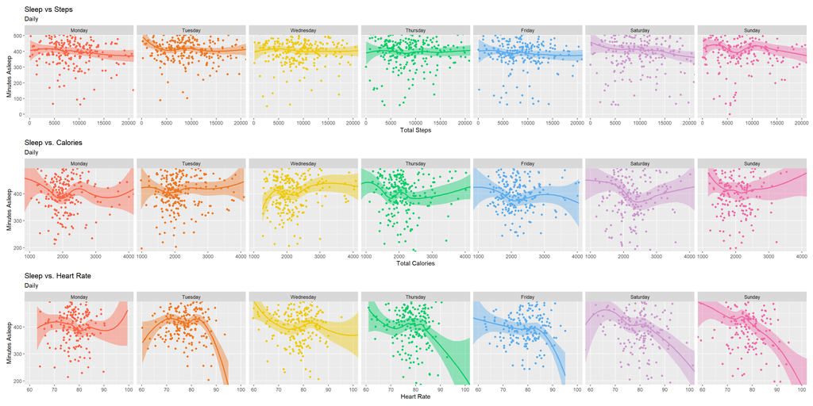

Notes:

- There are no noticeable trends by day that differ from the overall daily analysis.

Comparing how calories correlate to steps and heart rate.

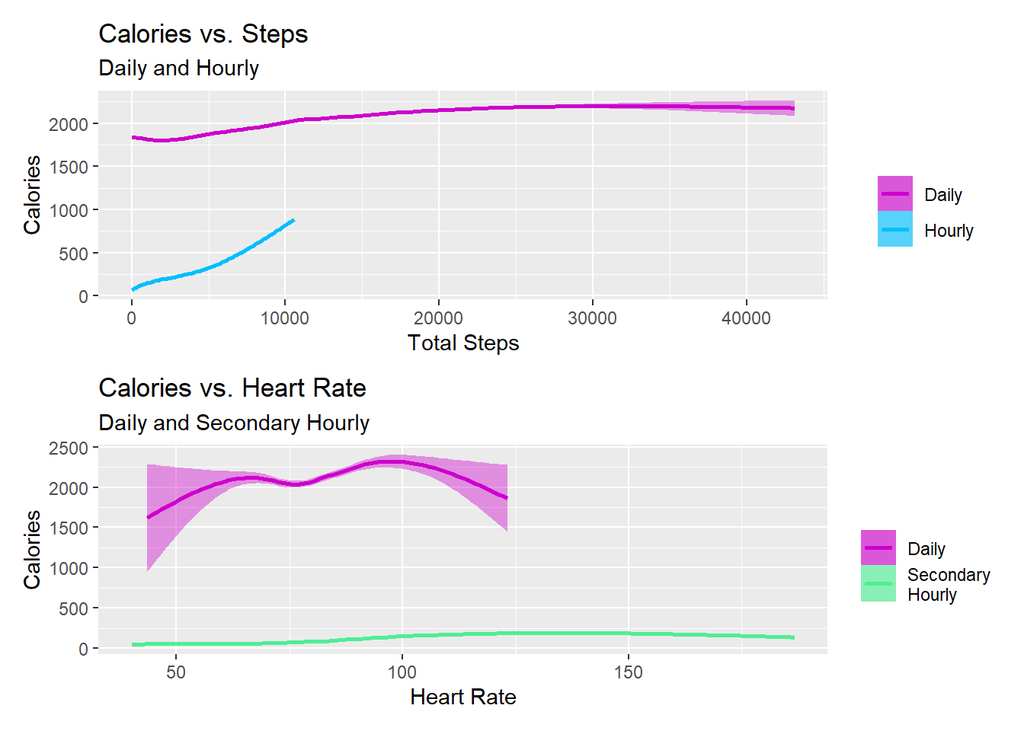

Finally, let’s compare how steps and heart rate correlate.

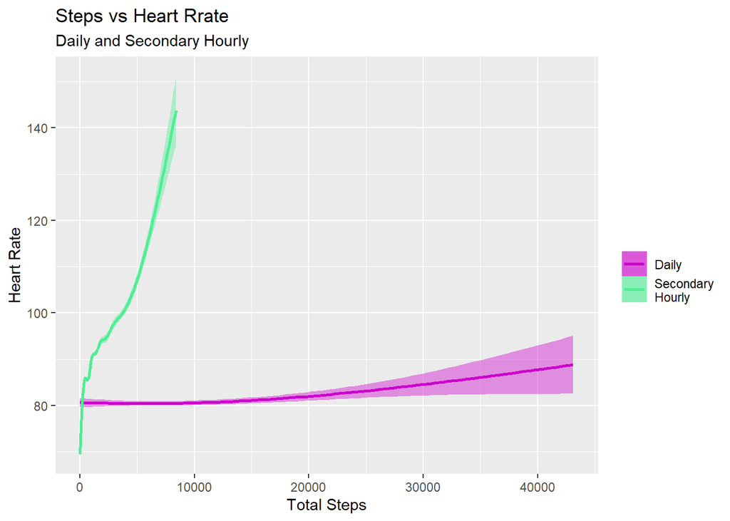

### **Conculsions**

#### Case Study Thoughts

- This was a great case study to perform. I already see room for improvement in future projects, but overall this was a great learning experience. I enjoyed learning and utilizing R for this project and look forward to many more future projects with it.
- I would appreciate any feedback as I continue to improve. Thank you for taking the time to read this case study.

### Appendix: All code for this report

```r
#Install and Load Packages
#install.packages("tidyverse")
#install.packages("janitor")
#install.packages("dplyr")
#install.packages("skimr")
#install.packages("ggplot2")
#install.packages("collapse")
#install.packages("patchwork")
library(tidyverse)
library(janitor)
library(dplyr)
library(skimr)
library(ggplot2)
library(collapse)
library(patchwork)

#Upload Primary Dataset
daily_calories <- read.csv("dailyCalories_merged.csv")
daily_steps <- read.csv("dailySteps_merged.csv")
hourly_calories <- read.csv("hourlyCalories_merged.csv")
hourly_steps <- read.csv("hourlySteps_merged.csv")
heartrate <- read.csv("heartrate_seconds_merged.csv")
daily_sleep <- read.csv("sleepDay_merged.csv")

#Upload Secondary Dataset
lifesnap_daily <- read.csv("Lifesnap/daily_fitbit_sema_df_unprocessed.csv")
lifesnap_hourly <- read.csv("Lifesnap/hourly_fitbit_sema_df_unprocessed.csv")

#Filtering Lifesnap Data
filtered_lifesnap_daily <- filter(lifesnap_daily, gender == 'FEMALE') %>%
  select(id, date, calories, steps, bpm,  minutesAsleep, gender)
filtered_lifesnap_hourly <- filter(lifesnap_hourly, gender == 'FEMALE') %>%
  select(id, date, hour, calories, steps, bpm, gender)

#Clean Names
daily_calories <- daily_calories %>% clean_names()
daily_steps <- daily_steps %>% clean_names()
hourly_calories <- hourly_calories %>% clean_names()
hourly_steps <- hourly_steps %>% clean_names()
heartrate <- heartrate %>% clean_names()
daily_sleep <- daily_sleep %>% clean_names()
filtered_lifesnap_daily <- filtered_lifesnap_daily %>% clean_names()
filtered_lifesnap_hourly <- filtered_lifesnap_hourly %>% clean_names()

#Reformat Date in Secondary
filtered_lifesnap_daily$date <- strftime(filtered_lifesnap_daily$date, format = "%m/%d/%Y", tz = "GMT")
filtered_lifesnap_hourly$date <- strftime(filtered_lifesnap_hourly$date, format = "%m/%d/%Y", tz = "GMT")

#Rename Daily Date Columns and Convert to Date Class
daily_calories = rename(daily_calories, "date" = "activity_day")
daily_calories$date <- mdy(daily_calories$date)
daily_calories$date <- strftime(daily_calories$date, "%m/%d/%Y", tz = "GMT")
daily_steps = rename(daily_steps, "date" = "activity_day")
daily_steps$date <- mdy(daily_steps$date)
daily_steps$date <- strftime(daily_steps$date, "%m/%d/%Y", tz = "GMT")
daily_sleep <- rename(daily_sleep, "minutes_asleep" = "total_minutes_asleep")
heartrate <- rename(heartrate, "bpm" = "value")
filtered_lifesnap_daily <- rename(filtered_lifesnap_daily, "minutes_asleep" = "minutes_asleep")

#Split and Rename Hourly Date and Hour Columns
hourly_calories$ActivityHour2 <- mdy_hms(hourly_calories$activity_hour)
hourly_calories$date <- strftime(hourly_calories$ActivityHour2, "%m/%d/%Y", tz = "GMT")
hourly_calories$hour <- parse_number(format(as.POSIXct(hourly_calories$ActivityHour2), format = "%H:%M:%S"))
hourly_calories <- subset(hourly_calories, select = -ActivityHour2)
hourly_steps$ActivityHour2 <- mdy_hms(hourly_steps$activity_hour)
hourly_steps$date <- strftime(hourly_steps$ActivityHour2, "%m/%d/%Y", tz = "GMT")
hourly_steps$hour <- parse_number(format(as.POSIXct(hourly_steps$ActivityHour2), format = "%H:%M:%S"))
hourly_steps <- subset(hourly_steps, select = -ActivityHour2)
daily_sleep$SleepDay2 <- mdy_hms(daily_sleep$sleep_day)
daily_sleep$date <- strftime(daily_sleep$SleepDay2, "%m/%d/%Y", tz = "GMT")
daily_sleep <- subset(daily_sleep, select = -SleepDay2)
heartrate$Time2 <- mdy_hms(heartrate$time)
heartrate$date <- strftime(heartrate$Time2, "%m/%d/%Y", tz = "GMT")
heartrate$hour <- parse_number(format(as.POSIXct(heartrate$Time2), format = "%H:%M:%S"))
heartrate <- subset(heartrate, select = -Time2)

#Convert Heart Rate id to Character
heartrate$id <- as.character(heartrate$id)

#Summarize Heart Rate Primary Data
daily_heartrate <- heartrate
daily_heartrate <-  daily_heartrate %>%
  mutate(bpm = bpm) %>%
  bind_rows(daily_heartrate) %>%
  group_by(id, date) %>%
  summarise(bpm = mean(bpm))

hourly_heartrate <- heartrate
hourly_heartrate <- hourly_heartrate %>%
  mutate(bpm = bpm) %>%
  bind_rows(hourly_heartrate) %>%
  group_by(id, date, hour) %>%
  summarise(bpm = mean(bpm))

#Add Day of Week
daily_calories$day <- mdy(daily_calories$date)
daily_calories$day <- weekdays(daily_calories$day, abbreviate = FALSE)
daily_steps$day <- mdy(daily_steps$date)
daily_steps$day <- weekdays(daily_steps$day, abbreviate = FALSE)
daily_sleep$day <- mdy(daily_sleep$date)
daily_sleep$day <- weekdays(daily_sleep$day, abbreviate = FALSE)
daily_heartrate$day <- mdy(daily_heartrate$date)
daily_heartrate$day <- weekdays(daily_heartrate$day, abbreviate = FALSE)
filtered_lifesnap_daily$day <- mdy(filtered_lifesnap_daily$date)
filtered_lifesnap_daily$day <- weekdays(filtered_lifesnap_daily$day, abbreviate = FALSE)

#Calculate Number of Primary Users
length(unique(daily_calories$id))
length(unique(hourly_steps$id))
length(unique(daily_steps$id))
length(unique(hourly_calories$id))
length(unique(daily_sleep$id))
length(unique(daily_heartrate$id))
length(unique(hourly_heartrate$id))

#Calculate Number of Seconary Users
length(unique(filtered_lifesnap_daily$id))
length(unique(filtered_lifesnap_hourly$id))

#Calculating the Calorie Difference Amounts
calories_verify <- hourly_calories %>%
  select(id, calories, date) %>%
  group_by(id, date) %>%
  summarise(total_calories=sum(calories)) %>%
  left_join(daily_calories) %>%
  mutate(calorie_difference = calories - total_calories)
tibble(calories_verify)

#Calculating the Step Difference Amounts
steps_verify <- hourly_steps %>%
  select(id, step_total, date) %>%
  group_by(id, date) %>%
  summarise(total_steps = sum(step_total)) %>%
  left_join(daily_steps) %>%
  mutate(step_difference = step_total - total_steps)
tibble(steps_verify)

#Calculating the Min, Max, and Total Differences
difference_totals_calories <- sum(calories_verify$calorie_difference)
minimum_calorie_difference <- min(calories_verify$calorie_difference)
maximum_calorie_difference <- max(calories_verify$calorie_difference)
difference_totals_steps <- sum(steps_verify$step_difference)
minimum_step_difference <- min(steps_verify$step_difference)
maximum_step_difference <- max(steps_verify$step_difference)
difference_totals_final <- data.frame(
  difference_totals_calories,
  minimum_calorie_difference,
  maximum_calorie_difference,
  difference_totals_steps,
  minimum_step_difference,
  maximum_step_difference
)
difference_totals <- pivot_longer(difference_totals_final, cols = contains("differ"), names_to = "type", values_to = "amount")
tibble(difference_totals_final)
```

```r
#Calculating Mean for Steps
mm_primary_hourly_steps <- data.frame(
  hour = c(0:23),
  mean = fmean(hourly_steps$step_total, g = hourly_steps$hour, na.rm=TRUE))

mm_secondary_hourly_steps <- data.frame(
  hour = c(0:23),
  mean = fmean(filtered_lifesnap_hourly$steps, g = filtered_lifesnap_hourly$hour, na.rm=TRUE))

mm_primary_daily_steps <- daily_steps %>%
  group_by(day) %>%
  summarise(mean = mean(step_total, na.rm = TRUE))

mm_secondary_daily_steps <- filtered_lifesnap_daily %>%
    group_by(day) %>%
  summarise(mean = mean(steps, na.rm = TRUE))

#Calculating Mean for Calories
mm_primary_hourly_calories <- data.frame(
  hour = c(0:23),
  mean = fmean(hourly_calories$calories, g = hourly_calories$hour, na.rm=TRUE))

mm_secondary_hourly_calories <- data.frame(
  hour = c(0:23),
  mean = fmean(filtered_lifesnap_hourly$calories, g = filtered_lifesnap_hourly$hour, na.rm=TRUE))

mm_primary_daily_calories <- daily_calories %>%
  group_by(day) %>%
  summarise(mean = mean(calories, na.rm = TRUE))

mm_secondary_daily_calories <- filtered_lifesnap_daily %>%
    group_by(day) %>%
  summarise(mean = mean(calories, na.rm = TRUE))

#Calculating Mean for Sleep
mm_primary_daily_sleep <- daily_sleep %>%
  group_by(day) %>%
  summarise(mean = mean(minutes_asleep, na.rm = TRUE))

mm_secondary_daily_sleep <- filtered_lifesnap_daily %>%
    group_by(day) %>%
  summarise(mean = mean(minutes_asleep, na.rm = TRUE))

#Calculating Mean for Heart rate
mm_primary_hourly_heartrate <- data.frame(
  hour = c(0:23),
  mean = fmean(heartrate$bpm, g = heartrate$hour, na.rm=TRUE))

mm_secondary_hourly_heartrate <- data.frame(
  hour = c(0:23),
  mean = fmean(filtered_lifesnap_hourly$bpm, g = filtered_lifesnap_hourly$hour, na.rm=TRUE))

mm_primary_daily_heartrate <- daily_heartrate %>%
  group_by(day) %>%
  summarise(mean = mean(bpm, na.rm = TRUE))

mm_secondary_daily_heartrate <- filtered_lifesnap_daily %>%
    group_by(day) %>%
  summarise(mean = mean(bpm, na.rm = TRUE))

#Creating a data.frame for the Day Display
xp <- list('Monday', 'Tuesday', 'Wednesday', 'Thursday', 'Friday', 'Saturday', 'Sunday')

#Primary vs Secondary Step Plots
daily1 <- ggplot(mapping = aes(x = hour, y = mean)) +
  geom_col(data = mm_secondary_hourly_steps, aes(fill=mean)) +
  scale_fill_gradient(low = "slateblue", high = "firebrick1", name = "Steps", guide = guide_legend(reverse = TRUE, order =1)) +
  geom_col(data = mm_primary_hourly_steps, aes(alpha =0.5)) +
  scale_alpha_continuous(name = "Primary", labels = "  ", guide_legend(order =2)) +
  geom_point(data =mm_primary_hourly_steps, aes(x=hour)) +
  ggtitle("Average Hourly Steps",
          subtitle = "Primary vs Secondary Datatset")  +
  scale_x_continuous(breaks = seq(0,23 , by = 6)) +
  xlab("Hour of the Day (24HR)") +
  ylab("Average Steps") +
  coord_cartesian(ylim = c(0, 850)) +
  theme(legend.key.size = unit(.5, 'cm'))

hourly1 <- ggplot(mapping = aes(x = factor(day, level=xp), y = mean)) +
  geom_col(data = mm_secondary_daily_steps, aes(fill=day)) +
  scale_fill_manual(values = c('firebrick1', 'chocolate1', 'khaki',  'mediumseagreen', 'slateblue',  'mediumorchid', 'palevioletred'), name = "Steps", guide = guide_legend(reverse = FALSE, order =1), limits=xp) +
  geom_col(data = mm_primary_daily_steps, aes(alpha=.5)) +
  scale_alpha_continuous(name = "Primary", labels = "  ", guide_legend(order =2)) +
  geom_point(data =mm_primary_daily_steps, aes(x=day)) +
  ggtitle("Average Daily Steps",
          subtitle = "Scondary Datatset") +
  xlab("Day of the Week") +
  ylab("Average Steps") +
  coord_cartesian(ylim = c(0, 10000)) +
  theme(legend.key.size = unit(.5, 'cm'))
daily1 / hourly1

#Primary vs Secondary Calories Plots
daily2 <- ggplot(mapping = aes(x = hour, y = mean)) +
  geom_col(data = mm_primary_hourly_calories, aes(fill=mean)) +
  scale_fill_gradient(low = "deepskyblue", high = "indianred2", name = "Calories", guide = guide_legend(reverse = TRUE, order =1)) +
  geom_col(data = mm_secondary_hourly_calories, aes(alpha =0.5)) +
  scale_alpha_continuous(name = "Secondary", labels = "  ", guide_legend(order =2)) +
  geom_point(data =mm_secondary_hourly_calories, aes(x=hour)) +
  ggtitle("Average Hourly Calories",
          subtitle = "Primary vs. Secondary Datatset")  +
  xlab("Hour of the Day (24HR)") +
  ylab("Average Calories") +
  scale_x_continuous(breaks = seq(0,23 , by = 6)) +
  coord_cartesian(ylim = c(0, 120)) +
  theme(legend.key.size = unit(.5, 'cm'))

hourly2 <- ggplot(mapping = aes(x = factor(day, level=xp), y = mean)) +
  geom_col(data = mm_primary_daily_calories, aes(fill=day)) +
  scale_fill_manual(values = c('indianred2', 'goldenrod2', 'lightgoldenrod2', 'seagreen2', 'deepskyblue', 'magenta3', 'maroon1'), name = "Calories", guide = guide_legend(reverse = FALSE, order =1), limits=xp) +
  geom_col(data = mm_secondary_daily_calories, aes(alpha=.5)) +
  scale_alpha_continuous(name = "Secondary", labels = "  ", guide_legend(order =2)) +
  geom_point(data =mm_secondary_daily_calories, aes(x=day)) +
  ggtitle("Average Daily Calories", subtitle = "Primary vs Secondary Datatset")  +
  xlab("Day of the Week") +
  ylab("Average Calories") +
  coord_cartesian(ylim = c(0, 2500)) +
  theme(legend.key.size = unit(.5, 'cm'))
daily2 / hourly2

#Primary vs Secondary Sleep Plot
daily4 <- ggplot(mapping = aes(x = factor(day, level=xp), y = mean)) +
  geom_col(data = mm_primary_daily_sleep, aes(fill=day)) +
  scale_fill_manual(values = c('tomato', 'chocolate2', 'gold2', 'springgreen3', 'steelblue2', 'plum3', 'hotpink2'), name = "Calories", guide = guide_legend(reverse = FALSE, order =1), limits=xp) +
  geom_col(data = mm_secondary_daily_sleep, aes(alpha=.5)) +
  scale_alpha_continuous(name = "Secondary", labels = "  ", guide_legend(order =2)) +
  geom_point(data =mm_secondary_daily_sleep, aes(x=day)) +
  ggtitle("Average Daily Sleep",
          subtitle = "Scondary Datatset") +
  xlab("Day of the Week") +
  ylab("Average Minutes Asleep") +
  coord_cartesian(ylim = c(0, 475)) +
  theme(legend.key.size = unit(.5, 'cm'))
daily4
```

```r
#Primary vs Secondary Heart rate Plots
daily3 <- ggplot(mapping = aes(x = hour, y = mean)) +
  geom_col(data = mm_secondary_hourly_heartrate, aes(fill=mean)) +
  scale_fill_gradient(low = "yellow", high = "red", name = "Steps", guide = guide_legend(reverse = TRUE, order =1)) +
  geom_col(data = mm_primary_hourly_heartrate, aes(alpha =0.5)) +
  scale_alpha_continuous(name = "Primary", labels = "  ", guide_legend(order =2)) +
  geom_point(data =mm_primary_hourly_heartrate, aes(x=hour)) +
  ggtitle("Average Hourly Heart Rate",
          subtitle = "Secondary Datatset")  +
  scale_x_continuous(breaks = seq(0,23 , by = 6)) +
  xlab("Hour of the Day (24HR)") +
  ylab("Average Heart Rate") +
  coord_cartesian(ylim = c(0, 90)) +
  theme(legend.key.size = unit(.5, 'cm'))

hourly3 <- ggplot(mapping = aes(x = factor(day, level=xp), y = mean)) +
  geom_col(data = mm_secondary_daily_heartrate, aes(fill=day)) +
  scale_fill_manual(values = c('red', 'orange', 'yellow', 'green', 'blue', 'violet', 'pink'), name = "Steps", guide = guide_legend(reverse = FALSE, order =1), limits=xp) +
  geom_col(data = mm_primary_daily_heartrate, aes(alpha=.5)) +
  scale_alpha_continuous(name = "Primary", labels = "  ", guide_legend(order =2)) +
  geom_point(data =mm_primary_daily_heartrate, aes(x=day)) +
  ggtitle("Average Daily Heart Rate",
          subtitle = "Primary vs Scondary Datatset") +
  xlab("Day of the Week") +
  ylab("Average Heart Rate") +
  coord_cartesian(ylim = c(0, 85)) +
  theme(legend.key.size = unit(.5, 'cm'))
daily3 / hourly3

#Combine Daily Datasets
daily_calories_filtered_lifesnap <- filtered_lifesnap_daily %>%
  select(id, date, calories, day)
combined_daily_calories <- rbind(daily_calories, daily_calories_filtered_lifesnap)

hourly_calories_filtered_lifesnap <- filtered_lifesnap_hourly %>%
  select(id, activity_hour=hour, calories, date, hour=hour)
combined_hourly_calories <- rbind(hourly_calories, hourly_calories_filtered_lifesnap)

daily_steps_filtered_lifesnap <- filtered_lifesnap_daily %>%
  select(id, date, step_total=steps, day)
combined_daily_steps <- rbind(daily_steps, daily_steps_filtered_lifesnap)

hourly_steps_filtered_lifesnap <- filtered_lifesnap_hourly %>%
  select(id, activity_hour=hour, step_total=steps, date, hour=hour)
combined_hourly_steps <- rbind(hourly_steps, hourly_steps_filtered_lifesnap)

daily_sleep_filtered_lifesnap <- filtered_lifesnap_daily %>%
  select(id, sleep_day=day, total_sleep_records=minutes_asleep, minutes_asleep=minutes_asleep, total_time_in_bed=minutes_asleep, date, day=day)
combined_daily_sleep <- rbind(daily_sleep, daily_sleep_filtered_lifesnap)

daily_heartrate_filtered_lifesnap <- filtered_lifesnap_daily %>%
  select(id, date, bpm, day)
combined_daily_heartrate <- rbind(daily_heartrate, daily_heartrate_filtered_lifesnap)

hourly_heartrate_filtered_lifesnap <- filtered_lifesnap_hourly %>%
  select(id, time=hour, bpm, date, hour=hour, day=date)
combined_hourly_heartrate <- rbind(hourly_heartrate, hourly_heartrate_filtered_lifesnap)

#Compare Total Sleep to Calories, Steps, and Heart Rate
combined_daily_sleep_calories <- merge(combined_daily_sleep, combined_daily_calories, by = c("id", "date"))
combined_daily_sleep_steps <- merge(combined_daily_sleep, combined_daily_steps, by=c("id", "date"))
combined_daily_sleep_heartrate <- merge(combined_daily_sleep, combined_daily_heartrate, by = c("id", "date"))
combined_daily_sleep_heartrate = rename(combined_daily_sleep_heartrate, "day" = "day.x")

sleep1 <-
  ggplot(data=combined_daily_sleep_steps, aes(x=step_total, y=minutes_asleep)) +
  geom_point(colour = "mediumseagreen", alpha = .3) +
  geom_smooth(colour = "mediumseagreen", linewidth =2) +
  ggtitle("Sleep vs. Steps",
          subtitle = "Daily") +
  xlab("Total Steps") +
  ylab("Minutes Asleep")  +
  coord_cartesian(ylim = c(0, 480), xlim = c(0, 20000))

sleep2 <- ggplot(data=combined_daily_sleep_calories, aes(x=calories, y=minutes_asleep)) +
  geom_point(color = "goldenrod2", alpha =.3) +
  geom_smooth(color = 'goldenrod2', linewidth =2) +
  ggtitle("Sleep vs. Calories",
          subtitle = "Daily") +
  xlab("Total Calories") +
  ylab("Minutes Asleep") +
  coord_cartesian(ylim = c(0, 480), xlim = c(1000, 4000))

sleep3 <- ggplot(data=combined_daily_sleep_heartrate, aes(x=bpm, y=minutes_asleep)) +
  geom_point(color = 'red', alpha =.3) +
  geom_smooth(color = 'red') +
  ggtitle("Sleep vs. Heart Rate",
          subtitle = "Daily") +
  xlab("Heart Rate") +
  ylab("Minutes Asleep") +
  coord_cartesian(ylim = c(0, 480), xlim = c(60, 100))
sleep1 +sleep2 +sleep3

#Compare Sleep by Day to Calories, Steps, and Heart Rate
sleep4 <- combined_daily_sleep_steps %>%
  ggplot(aes(x = step_total, y = minutes_asleep, color = day.x, fill = day.x)) +
  geom_point(show.legend = FALSE) +
  geom_smooth( show.legend = FALSE) +
  facet_wrap(~factor(day.x, levels = xp), ncol=7) +
  scale_fill_manual(values = c('tomato', 'chocolate2', 'gold2', 'springgreen3', 'steelblue2', 'plum3', 'hotpink2'), limits=xp) +
  scale_color_manual(values = c('tomato', 'chocolate2', 'gold2', 'springgreen3', 'steelblue2', 'plum3', 'hotpink2'), limits=xp) +
  ggtitle("Sleep vs Steps",
          subtitle = "Daily") +
  xlab("Total Steps") +
  ylab("Minutes Asleep")  +
  coord_cartesian(ylim = c(00, 480), xlim = c(0, 20000))

sleep5 <- combined_daily_sleep_calories %>%
 ggplot(aes(x = calories, y = minutes_asleep, colour = day.x, fill = day.x)) +
  geom_point(show.legend = FALSE) +
  geom_smooth( show.legend = FALSE) +
  facet_wrap(~factor(day.x, levels = xp), ncol=7) +
  scale_fill_manual(values = c('tomato', 'chocolate2', 'gold2', 'springgreen3', 'steelblue2', 'plum3', 'hotpink2'), limits=xp) +
  scale_color_manual(values = c('tomato', 'chocolate2', 'gold2', 'springgreen3', 'steelblue2', 'plum3', 'hotpink2'), limits=xp) +
  ggtitle("Sleep vs. Calories",
          subtitle = "Daily") +
  xlab("Total Calories") +
  ylab("Minutes Asleep") +
  coord_cartesian(ylim = c(200, 480), xlim = c(1000, 4000))

sleep6 <- combined_daily_sleep_heartrate %>%
  ggplot(aes(x = bpm, y = minutes_asleep, colour = day, fill = day)) +
  geom_point(show.legend = FALSE) +
  geom_smooth( show.legend = FALSE) +
  facet_wrap(~factor(day, levels = xp), ncol=7) +
  scale_fill_manual(values = c('tomato', 'chocolate2', 'gold2', 'springgreen3', 'steelblue2', 'plum3', 'hotpink2'), limits=xp) +
  scale_color_manual(values = c('tomato', 'chocolate2', 'gold2', 'springgreen3', 'steelblue2', 'plum3', 'hotpink2'), limits=xp) +
  ggtitle("Sleep vs. Heart Rate",
          subtitle = "Daily") +
  xlab("Heart Rate") +
  ylab("Minutes Asleep") +
  coord_cartesian(ylim = c(200, 480), xlim = c(60, 100))
sleep4 /sleep5 / sleep6
```

```r
#Compare Calories to Steps and Heart Rate
combined_daily_calories_steps <- merge(combined_daily_calories, combined_daily_steps, by ="id")
combined_hourly_calories_steps <- cbind(combined_hourly_calories, combined_hourly_steps)
combined_hourly_calories_steps <- combined_hourly_calories_steps %>%  clean_names()
combined_daily_calories_heartrate <- merge(combined_daily_calories, combined_daily_heartrate, by =c("id", "date"))

calories1 <- ggplot(mapping = aes(x=step_total, y=calories, color=calories)) +
  geom_smooth(data=combined_daily_calories_steps, aes(color="Daily", fill="Daily")) +
  geom_smooth(data = combined_hourly_calories_steps, aes(color = "Hourly", fill="Hourly")) +
  scale_colour_manual(name=" ", values=c("magenta3", "deepskyblue")) +
  scale_fill_manual(" ", values = c("magenta3", "deepskyblue"))  +
  ggtitle("Calories vs. Steps",
          subtitle = "Daily and Hourly") +
  xlab("Total Steps") +
  ylab("Calories")

calories2 <- ggplot(mapping = aes(x=bpm, y=calories, color=calories)) +
  geom_smooth(data=combined_daily_calories_heartrate, aes(color="Daily", fill="Daily")) +
  geom_smooth(data = filtered_lifesnap_hourly, aes(color = "Secondary Hourly", fill="Secondary Hourly")) +
  scale_colour_manual(name=" ", values=c("magenta3", "seagreen2"), label = ~str_wrap(.x, width = 10)) +
  scale_fill_manual(" ", values = c("magenta3", "seagreen2"), label = ~str_wrap(.x, width = 10))  +
  ggtitle("Calories vs. Heart Rate",
          subtitle = "Daily and Secondary Hourly") +
  xlab("Heart Rate") +
  ylab("Calories")
calories1 / calories2

#Compare Steps and Heart Rate
combined_daily_steps_heartrate <- merge(combined_daily_steps, combined_daily_heartrate, by =c("id", "date"))
filtered_lifesnap_hourly <- rename(filtered_lifesnap_hourly, "step_total" = "steps")

ggplot(mapping = aes(x=step_total, y=bpm, color=bpm)) +
  geom_smooth(data=combined_daily_steps_heartrate, aes(color="Daily", fill="Daily")) +
  geom_smooth(data =filtered_lifesnap_hourly, aes(color = "Secondary Hourly", fill="Secondary Hourly")) +
  scale_colour_manual(name=" ", values=c("magenta3", "seagreen2"), label = ~str_wrap(.x, width = 10)) +
  scale_fill_manual(" ", values = c("magenta3", "seagreen2"), label = ~str_wrap(.x, width = 10))  +
  ggtitle("Steps vs Heart Rrate",
          subtitle = "Daily and Secondary Hourly") +
  xlab("Total Steps") +
  ylab("Heart Rate")
```